# 糖尿病预测实验复现与改进

## 实验说明

该数据集(pima-indians-diabetes.data)是来自美国疾病控制预防中心的数据，背景是记录美国的糖尿病症状信息，现在美国1/7的成年人患有糖尿病。但是到2050年，这个比例将会快速增长至高达1/3。可以利用从UCI机器学习数据库里一个关于印第安人糖尿病数据集，通过数据挖掘相关算法来预测糖尿病，该问题本质上是一个二元分类问题。

## 实验环境

- Python 3.7.9
- imbalanced-learn 0.12.4
- matplotlib 3.5.3
- numpy 1.21.6
- pandas 1.3.5
- scikit-learn 1.0.2
- seaborn 0.12.2
- xgBoost 1.6.2

## 实验复现

按照实验手册的指导进行

### 步骤1 载入本地数据集(pima-indians-diabetes.data)，以dataframe形式存放后，命名为df。

```python
import pandas as pd
# 读取 CSV 文件
df = pd.read_csv(r'pima-indians-diabetes.data')
```

### 步骤2 查看数据尺寸,打印信息，判断特征的类型（名称性、数值型），目标变量分布以及查看是否均衡。

以下是数据集的尺寸、相关信息和特征类型。可以看到数据集共768个数据点，共有9个特征，分别为怀孕次数（Pregnancies）、血糖（Gulcose）、血压（BloodPressure）、皮脂厚度（SkinThickness）、胰岛素（Insulin）、身体质量指数（BMI）、糖尿病遗传函数（DiabetesPedigreeFunction）、年龄（Age）、结果（Outcome）。其中Outcome为0或1，1表示患有糖尿病，0表示未患病。

```python
# 查看数据尺寸
print(df.shape)
# 查看数据信息
print(df.info())
```

```
(768, 9)
<class 'pandas.core.frame.DataFrame'>
RangeIndex: 768 entries, 0 to 767
Data columns (total 9 columns):
 #   Column                   Non-Null Count  Dtype
---  ------                   --------------  -----
 0   Pregnancies              768 non-null    int64
 1   Glucose                  768 non-null    int64
 2   BloodPressure            768 non-null    int64
 3   SkinThickness            768 non-null    int64
 4   Insulin                  768 non-null    int64
 5   BMI                      768 non-null    float64
 6   DiabetesPedigreeFuction  768 non-null    float64
 7   Age                      768 non-null    int64
 8   Outcome                  768 non-null    int64
dtypes: float64(2), int64(7)
memory usage: 54.1 KB
None
```

以下为数据集的各项统计信息。

```python
# 查看数据统计描述
print(df.describe())
```

```
       Pregnancies     Glucose  BloodPressure  SkinThickness     Insulin  \
count   768.000000  768.000000     768.000000     768.000000  768.000000
mean      3.845052  120.894531      69.105469      20.536458   79.799479
std       3.369578   31.972618      19.355807      15.952218  115.244002
min       0.000000    0.000000       0.000000       0.000000    0.000000
25%       1.000000   99.000000      62.000000       0.000000    0.000000
50%       3.000000  117.000000      72.000000      23.000000   30.500000
75%       6.000000  140.250000      80.000000      32.000000  127.250000
max      17.000000  199.000000     122.000000      99.000000  846.000000

              BMI  DiabetesPedigreeFuction         Age     Outcome
count  768.000000               768.000000  768.000000  768.000000
mean    31.992578                 0.472396   33.240885    0.348958
std      7.884160                 0.331242   11.760232    0.476951
min      0.000000                 0.080000   21.000000    0.000000
25%     27.300000                 0.240000   24.000000    0.000000
50%     32.000000                 0.370000   29.000000    0.000000
75%     36.600000                 0.630000   41.000000    1.000000
max     67.100000                 2.420000   81.000000    1.000000
```

以下为目标变量分布，可以看出目标变量不够均衡。如果直接使用，可能会影响模型的效果

```
目标变量分布比例:
 0    0.651042
1    0.348958
Name: Outcome, dtype: float64
```

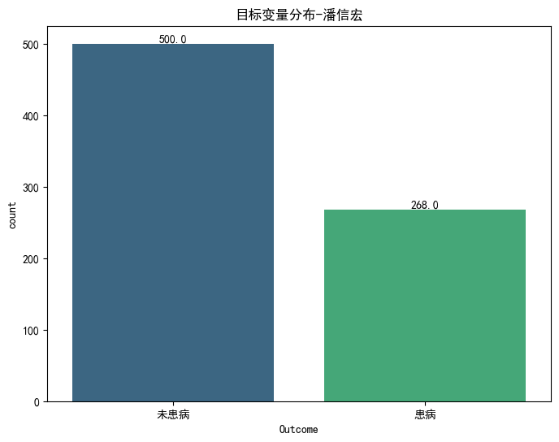

```python
import matplotlib.pyplot as plt
import seaborn as sns
# 设置中文字体
plt.rcParams['font.sans-serif'] = ['SimHei']

# 查看目标变量 'Outcome' 的分布比例
outcome_distribution_normalized = df['Outcome'].value_counts(normalize=True)
print("目标变量分布比例:\n", outcome_distribution_normalized)

# 使用柱状图可视化目标变量的分布
plt.figure(figsize=(8, 6))
sns.countplot(x='Outcome', data=df, palette='viridis')
plt.title('目标变量分布-潘信宏')
plt.xticks([0, 1], ['未患病', '患病'])
# 在每个柱子上显示数值
heights = [rect.get_height() for rect in plt.gca().patches]
for i, v in enumerate(heights):
    plt.text(i, v + 0.5, f'{v}', horizontalalignment='center', verticalalignment='bottom')
plt.show()
```

### 步骤3 对df特征进行相关性可视化

这里用spearman相关系数来衡量两个变量之间的线性相关程度。

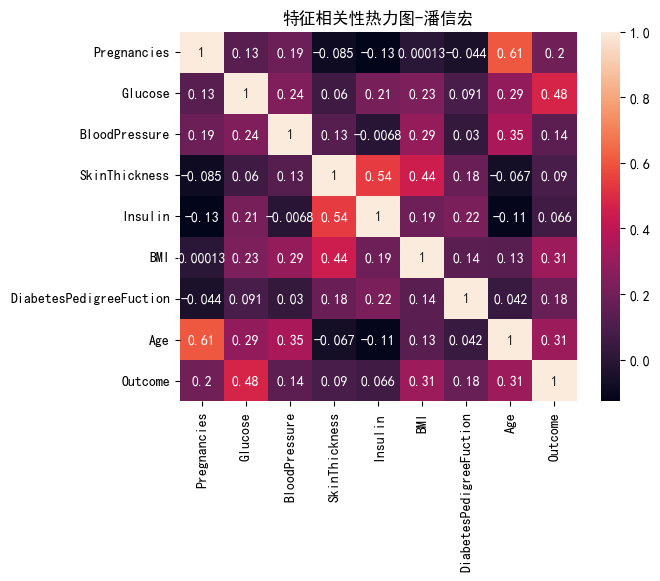

```python
%matplotlib inline
#计算特征相关性并可视化
plt.rcParams['font.sans-serif'] = ['SimHei']

corr_matrix = df.corr(method='spearman')
sns.heatmap(corr_matrix, annot= True)
plt.title('特征相关性热力图-潘信宏')
plt.show()
```

### 步骤4 对df每个特征的分布进行可视化查看

outcome变量的分布情况见上，其余变量的分布情况见下图。

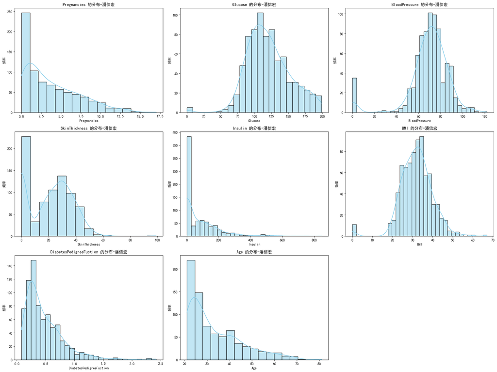

```python
plt.rcParams['font.sans-serif'] = ['SimHei']
plt.figure(figsize=(20, 15))
for i, column in enumerate(df.columns[:-1], 1):  # 排除目标变量 'Outcome'
    plt.subplot(3, 3, i)  # 3x3 的子图布局
    sns.histplot(df[column], kde=True, color='skyblue')
    plt.title(f'{column} 的分布-潘信宏')
    plt.xlabel(column)
    plt.ylabel('频率')
plt.tight_layout()
plt.show()
```

### 步骤5 对输入特征进行降维，选择PCA。

首先使用StandardScaler对输入特征X进行了标准化处理。标准化是降维技术中的一个重要步骤，它能确保每个特征对结果的影响是平等的。然后创建一个PCA对象，并指定n_components=0.99以保留99%的信息。最后，对标准化后的数据X_std应用PCA进行降维，得到新的特征矩阵X_pca。  
输入特征（X）：包含 8 个原始特征（如Glucose血糖、BMI体质指数等），用于模型学习。  
目标变量（y）：二分类标签（0 = 未患病，1 = 患病），是模型需要预测的结果。  
fit_transform：先计算训练数据的均值和标准差（fit），再应用标准化（transform）。  
输出X_std：标准化后的特征矩阵，各特征均值为 0，标准差为 1。  
n_components=0.99：自动选择最少的主成分数量，使得这些主成分的方差之和占原始数据总方差的 99%。例如，若原始 8 个特征的总方差为 100，降维后 k 个主成分的方差和为 99，则 k 即为最终保留的特征数。 X_pca：降维后的特征矩阵（n_samples × k），k 由 99% 的方差保留比例决定（例如可能 k=5，表示用 5 个主成分替代原始 8 个特征）。

```python
### 对输入特征进行降维处理
from sklearn.decomposition import PCA
from sklearn import preprocessing                 # 调用标准化模块

x_cols = [col for col in df.columns if col!='Outcome']
y_col = 'Outcome'
X=df[x_cols].values
y=df[y_col].values

scaler = preprocessing.StandardScaler()           # 创建标准化对象
X_std = scaler.fit_transform(X)                   # 对数据进行标准化

pca = PCA(n_components=0.99)                      # 保留99%信息的主成分个主成分
X_pca = pca.fit(X_std).transform(X_std)           # 应用PCA进行降维

print("新的特征矩阵:\n", X_pca)
```

```
新的特征矩阵:
 [[ 1.07033849  1.2343164   0.09729983 ...  0.35715829  0.85896619
   0.97355847]
 [-1.12260289 -0.73379895 -0.71533374 ... -0.40578054  0.75790965
   0.35348427]
 [-0.39888865  1.5967823   1.75659505 ... -0.03927386 -1.15181668
   1.06994571]
 ...
 [-0.2802779   0.09540732 -0.06855471 ... -0.54014265 -0.33609166
   0.28941066]
 [-1.06031347  0.83654985  0.42611237 ...  0.15292186  1.17949032
  -0.535553  ]
 [-0.83592506 -1.15376894 -1.00347735 ... -0.15124145  0.24480821
   0.51549661]]
```

### 步骤6 结合相关性分析和降维后的结论，选择数据进行拆分为训练集和测试集，拆分比例设置为0.1，指定以Target的比例做分层抽样。

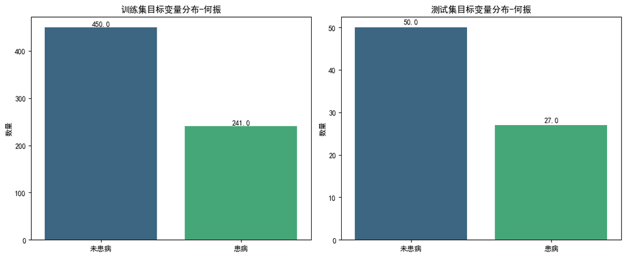

```python
from sklearn.model_selection import train_test_split
import matplotlib.pyplot as plt
import seaborn as sns

X = X_pca
X_train, X_test, y_train, y_test = train_test_split(X, y, test_size=0.1, stratify=y, random_state=42)


# 3. 可视化目标变量的分布
plt.figure(figsize=(12, 5))

plt.subplot(1, 2, 1)
sns.countplot(x=y_train, palette='viridis')
plt.title('训练集目标变量分布-何振')
plt.ylabel('数量')
plt.xticks([0, 1], ['未患病', '患病'])
heights = [rect.get_height() for rect in plt.gca().patches]
for i, v in enumerate(heights):
    plt.text(i, v + 0.5, f'{v}', horizontalalignment='center', verticalalignment='bottom')

plt.subplot(1, 2, 2)
sns.countplot(x=y_test, palette='viridis')
plt.title('测试集目标变量分布-何振')
plt.ylabel('数量')
plt.xticks([0, 1], ['未患病', '患病'])
heights = [rect.get_height() for rect in plt.gca().patches]
for i, v in enumerate(heights):
    plt.text(i, v + 0.5, f'{v}', horizontalalignment='center', verticalalignment='bottom')

plt.tight_layout()
plt.show()
```

### 步骤7 选择逻辑回归算法对拆分后的数据进行建模训练和预测，其中要求将原始模型做5折交叉验证，评估指标选择f1。

训练结果如下

```
5折交叉验证F1分数: [0.54320988 0.6744186  0.67391304 0.68965517 0.56097561]
交叉验证平均F1分数: 0.6284344613685049
训练集F1分数: 0.6431924882629108
测试集F1分数: 0.6666666666666666
```

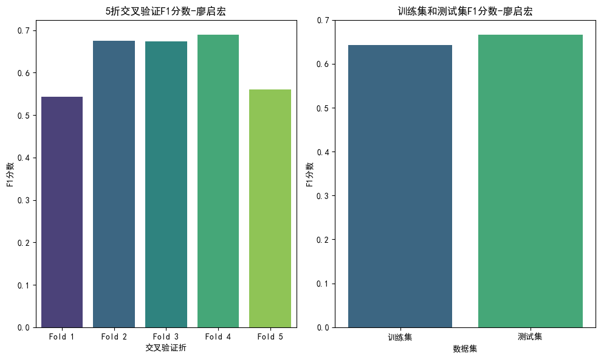

```python
#引入逻辑回归和交叉验证的库
from sklearn.linear_model import LogisticRegression
from sklearn.model_selection import cross_val_score

#引入评价指标的库
from sklearn.metrics import f1_score

# 创建逻辑回归模型
LogisticRegression_model = LogisticRegression(max_iter=1000, random_state=42)

# 使用5折交叉验证评估模型的F1分数
f1_scores = cross_val_score(LogisticRegression_model, X_train, y_train, cv=5, scoring='f1')

# 打印交叉验证的F1分数
print(f"5折交叉验证F1分数: {f1_scores}")
print(f"交叉验证平均F1分数: {f1_scores.mean():}")

# 训练模型
LogisticRegression_model.fit(X_train, y_train)

# 进行预测
y_train_pred = LogisticRegression_model.predict(X_train)
y_test_pred = LogisticRegression_model.predict(X_test)

# 计算训练集和测试集的F1分数
f1_train = f1_score(y_train, y_train_pred)
f1_test = f1_score(y_test, y_test_pred)

print(f"训练集F1分数: {f1_train:}")
print(f"测试集F1分数: {f1_test:}")

#可视化F1分数的结果
plt.figure(figsize=(10, 6))

plt.subplot(1, 2, 1)
sns.barplot(x=['Fold 1', 'Fold 2', 'Fold 3', 'Fold 4', 'Fold 5'], y=f1_scores, palette='viridis')
plt.title('5折交叉验证F1分数-廖启宏')
plt.xlabel('交叉验证折')
plt.ylabel('F1分数')

plt.subplot(1, 2, 2)
sns.barplot(x=['训练集', '测试集'], y=[f1_train, f1_test], palette='viridis')
plt.title('训练集和测试集F1分数-廖启宏')
plt.xlabel('数据集')
plt.ylabel('F1分数')


plt.tight_layout()
plt.show()
```

### 步骤8 对逻辑回归的几个重要参数进行网格搜索

最佳参数如下

```python
from sklearn.model_selection import GridSearchCV

c_range=[0.001,0.01,0.1,1.0]
solvers = ['liblinear','lbfgs','newton-cg','sag']
max_iters=[80,100,150,200,300]
tuned_parameters= dict(solver=solvers, C=c_range,max_iter=max_iters)

lr_grid = GridSearchCV(LogisticRegression_model, param_grid=tuned_parameters, scoring='f1', cv=5)
lr_grid.fit(X_train, y_train)

# 输出最佳参数
print(f"最佳参数: {lr_grid.best_params_}")
print(f"最佳F1分数: {lr_grid.best_score_}")
```

```
最佳参数: {'C': 0.001, 'max_iter': 80, 'solver': 'liblinear'}
最佳F1分数: 0.6370429688514795
```

### 步骤9 根据搜索参数，最后确认模型，进行预测。

```python
from sklearn.metrics import classification_report, confusion_matrix

lr_best_model = lr_grid.best_estimator_

# 进行预测
y_test_pred = lr_best_model.predict(X_test)

# 计算测试集的F1分数
f1_test = f1_score(y_test, y_test_pred)

print(f"测试集F1分数: {f1_test}")
```

```
测试集F1分数: 0.6181818181818182
```

### 实验结果分析

#### 模型的分类报告

对测试集的真实标签与模型预测结果进行对比分析，生成包含多维度指标的评估报告。报告中会显示以下关键指标：

1. **精确率(Precision)**：预测为某类的样本中实际正确的比例（减少误诊）
2. **召回率(Recall)**：实际某类样本中被正确预测的比例（减少漏诊）
3. **F1分数**：精确率和召回率的调和平均数（综合评估）
4. **支持数(Support)**：每类的实际样本量 该报告能帮助研究者快速识别模型对不同类别的识别能力差异（例如本项目中糖尿病患者的识别效果），为后续模型优化提供量化依据。

```python
# 打印分类报告
print("\n分类报告-高远:")
print(classification_report(y_test, y_test_pred))
```

```
分类报告-高远:
              precision    recall  f1-score   support

           0       0.80      0.78      0.79        50
           1       0.61      0.63      0.62        27

    accuracy                           0.73        77
   macro avg       0.70      0.70      0.70        77
weighted avg       0.73      0.73      0.73        77
```

#### 模型的混淆矩阵

混淆矩阵（Confusion Matrix）是评估分类模型性能的重要工具，它以表格形式直观展示模型的预测结果与实际标签的对比情况。在这个糖尿病预测项目中，我们使用混淆矩阵来具体分析逻辑回归模型的分类表现，特别是区分"患病"和"未患病"两类时的准确性。通过矩阵中的真正例（TP）、真负例（TN）、假正例（FP）和假负例（FN），不仅能计算准确率、召回率、精确率等关键指标，也能识别模型的错误类型，比如模型漏诊（假阴性）比误诊（假阳性）更严重。此外，混淆矩阵还为优化模型提供了明确方向，比如可以通过调整分类阈值或改进特征工程来降低临床风险。

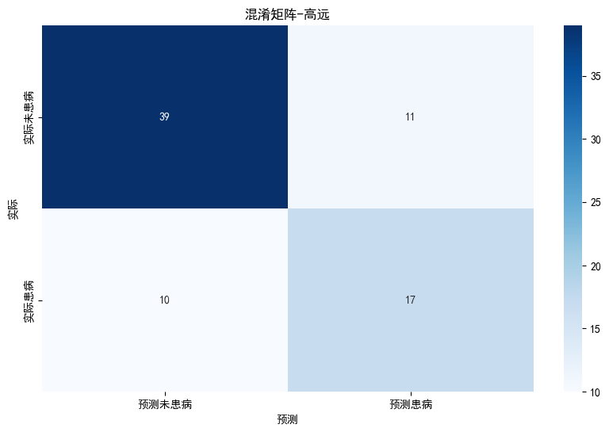

```python
# 绘制混淆矩阵
conf_matrix = confusion_matrix(y_test, y_test_pred)

plt.figure(figsize=(10, 6))
sns.heatmap(conf_matrix, annot=True, fmt='d', cmap='Blues', xticklabels=['预测未患病', '预测患病'], yticklabels=['实际未患病', '实际患病'])
plt.title('混淆矩阵-高远')
plt.xlabel('预测')
plt.ylabel('实际')
plt.show()
```

#### 模型的ROC曲线和AUC值

ROC曲线（Receiver Operating Characteristic Curve）通过展示分类器在不同阈值下的真阳性率（True Positive Rate, TPR）与假阳性率（False Positive Rate, FPR）之间的关系来评估分类器的性能。

AUC值（Area Under the Curve）是ROC曲线下的面积，AUC值越大，说明模型的分类效果越好。具体来说，AUC值可以解释为随机选取一个正样本和一个负样本，分类器能正确判断出哪个是正样本的概率。

以下是模型的ROC曲线和AUC值

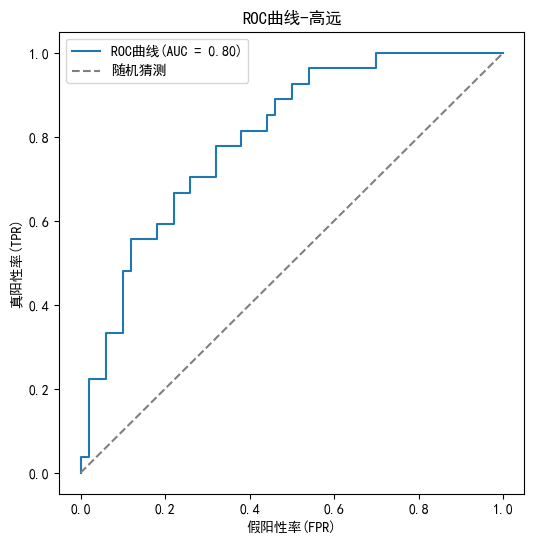

```python
from sklearn.metrics import roc_curve, roc_auc_score

# 计算预测概率
y_test_prob = lr_best_model.predict_proba(X_test)[:, 1]

# 计算ROC曲线
fpr, tpr, thresholds = roc_curve(y_test, y_test_prob)

# 计算AUC
auc_score = roc_auc_score(y_test, y_test_prob)

# 绘制ROC曲线
plt.figure(figsize=(6, 6))
plt.plot(fpr, tpr, label=f'ROC曲线(AUC = {auc_score:.2f})')
plt.plot([0, 1], [0, 1], linestyle='--', color='gray', label='随机猜测')
plt.xlabel('假阳性率(FPR)')
plt.ylabel('真阳性率(TPR)')
plt.title('ROC曲线-高远')
plt.legend()
plt.show()
```

#### 模型精确率-召回率曲线

精确率-召回率曲线（Precision-Recall Curve，PR曲线）是一种用于评估分类模型性能的图形工具，特别是在类别不平衡的情况下（例如在糖尿病预测这样的场景中，正样本和负样本的数量可能差异很大）。PR曲线展示了不同阈值下的精确率（Precision）与召回率（Recall）之间的关系。

精确率（Precision）：精确率是指在所有被预测为正的样本中，实际为正的比例。

召回率（Recall）：召回率是指在所有实际为正的样本中，被正确识别为正的比例。

PR曲线的作用：

- 在类别不平衡的情况下，ROC曲线可能会被误导，因为假阳性率（FPR）可能很高，即使分类器预测了很多负样本为正。而PR曲线通过关注精确率和召回率，能够更好地反映模型在正样本上的表现。
- PR曲线可以帮助用户根据具体问题的需求选择合适的分类器阈值。通过观察曲线，可以在精确率和召回率之间做出权衡，选择一个能够满足业务需求的阈值。
- PR曲线和其下的面积（AUC值）可以用于比较不同模型的性能。PR曲线下的面积（PR AUC）越接近1，表示模型的性能越好。

从图像来看，该模型性能一般

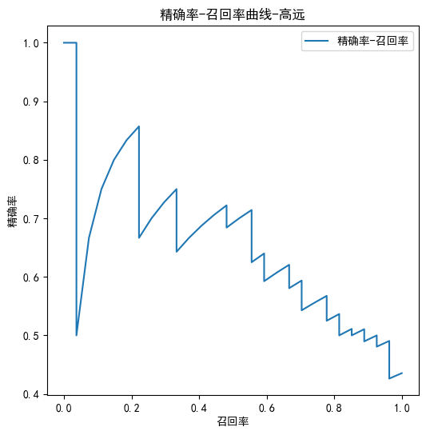

```python
from sklearn.metrics import precision_recall_curve

# 计算精确率-召回率曲线
precision, recall, thresholds = precision_recall_curve(y_test, y_test_prob)

# 绘制曲线
plt.figure(figsize=(6, 6))
plt.plot(recall, precision, label='精确率-召回率')
plt.xlabel('召回率')
plt.ylabel('精确率')
plt.title('精确率-召回率曲线-高远')
plt.legend()
plt.show()
```

经过上面的分析，能够得出以下几个结论

优点 ：

- AUC 值为0.80，表明模型在区分正负类样本方面表现较好。
- 在类别 0（多数类）上的精确率、召回率和 F1 分数较高，说明模型对多数类的识别能力较强。

缺点 ：

- 在类别 1（少数类）上的精确率、召回率和 F1 分数较低，说明模型对少数类的识别能力不足。
- 精确率-召回率曲线显示模型性能一般，尤其是在高召回率下精确率下降明显。
- 错误率较高（27%），表明模型在部分样本上预测不够准确。

### 改进方向

- 处理类别不平衡 ：使用过采样（如 SMOTE）或欠采样方法平衡类别分布；在模型训练时调整类别权重（如class_weight='balanced'）。
- 优化模型 ：尝试其他分类算法（如随机森林、XGBoost、支持向量机等）；使用网格搜索或随机搜索优化超参数。

## 实验改进

在复现的最后部分，我们小组分析了模型的效果不错，但是还有改进的空间，在改进中，我们组着重通过更换其他分类算法（如**随机森林**、**支持向量机**等）来综合比较这几种算法的效果。

### 实验改进 - 更换分类算法

#### 随机森林模型

```python
from sklearn.ensemble import RandomForestClassifier

# 初始化随机森林模型
rf_model = RandomForestClassifier(random_state=42)

# 定义超参数网格
rf_params = {
    'n_estimators': [100, 200],
    'max_depth': [None, 10, 20],
    'min_samples_split': [2, 5]
}

# 使用 GridSearchCV 进行网格搜索
rf_grid = GridSearchCV(rf_model, rf_params, cv=5, scoring='f1')
rf_grid.fit(X_train, y_train)

# 输出最佳 F1 分数和最佳参数
print('Random Forest Best F1 Score:', rf_grid.best_score_)
print('Random Forest Best Parameters:', rf_grid.best_params_)
```

```
Random Forest Best F1 Score: 0.6206047402125834
Random Forest Best Parameters: {'max_depth': None, 'min_samples_split': 5, 'n_estimators': 200}
```

#### 支持向量机模型

```python
import os
from sklearn.svm import SVC
from sklearn.model_selection import train_test_split

# 检查数据集大小
print(X_train.shape, y_train.shape)

# 使用数据子集
X_train_small, _, y_train_small, _ = train_test_split(X_train, y_train, train_size=0.1, random_state=42)

# 初始化 SVM 模型
svc_model = SVC(random_state=42, max_iter=1000, tol=1e-3, probability=True)  # 启用概率预测

# 定义超参数网格
svc_params = {
    'C': [0.1, 1],  # 减少 C 的取值
    'kernel': ['linear']  # 只使用线性核
}

# 使用 GridSearchCV 进行网格搜索
svc_grid = GridSearchCV(
    svc_model,
    svc_params,
    cv=3,  # 减少交叉验证折数
    scoring='f1',
    n_jobs=1  # 关闭并行计算
)

# 训练模型
svc_grid.fit(X_train_small, y_train_small)  # 使用数据子集

# 输出最佳 F1 分数和最佳参数
print('SVM Best F1 Score:', svc_grid.best_score_)
print('SVM Best Parameters:', svc_grid.best_params_)
```

```
(691, 8) (691,)
SVM Best F1 Score: 0.5407407407407407
SVM Best Parameters: {'C': 0.1, 'kernel': 'linear'}
```

#### K近邻模型

```python
os.environ["KMP_DUPLICATE_LIB_OK"]="TRUE"
from sklearn.neighbors import KNeighborsClassifier
knn_model = KNeighborsClassifier()
knn_params = {
    'n_neighbors': [3, 5, 7],
    'weights': ['uniform', 'distance']
}
knn_grid = GridSearchCV(knn_model, knn_params, cv=5, scoring='f1')
knn_grid.fit(X_train, y_train)
print('KNN Best F1 Score:', knn_grid.best_score_)
print('KNN Best Parameters:', knn_grid.best_params_)
```

```
KNN Best F1 Score: 0.5958267692047532
KNN Best Parameters: {'n_neighbors': 3, 'weights': 'uniform'}
```

#### XGBoost模型

```python
from xgboost import XGBClassifier

# 初始化 XGBoost 模型
xgb_model = XGBClassifier(random_state=42, use_label_encoder=False, eval_metric='logloss')

# 定义超参数网格
xgb_params = {
    'n_estimators': [100, 200],  # 树的数量
    'max_depth': [3, 5, 7],      # 树的最大深度
    'learning_rate': [0.01, 0.1], # 学习率
    'subsample': [0.8, 1.0]      # 样本子集比例
}

# 使用 GridSearchCV 进行网格搜索
xgb_grid = GridSearchCV(xgb_model, xgb_params, cv=5, scoring='f1')
xgb_grid.fit(X_train, y_train)

# 输出最佳 F1 分数和最佳参数
print('XGBoost Best F1 Score:', xgb_grid.best_score_)
print('XGBoost Best Parameters:', xgb_grid.best_params_)
```

```
XGBoost Best F1 Score: 0.6586125794349996
XGBoost Best Parameters: {'learning_rate': 0.1, 'max_depth': 3, 'n_estimators': 100, 'subsample': 0.8}
```

#### 对比各个模型的F1 Score

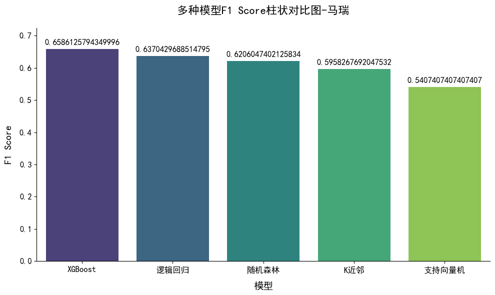

```python
import matplotlib.pyplot as plt
import seaborn as sns

results = {'逻辑回归': lr_grid.best_score_, '随机森林': rf_grid.best_score_,
           '支持向量机': svc_grid.best_score_, 'K近邻': knn_grid.best_score_,
           'XGBoost': xgb_grid.best_score_}

# 按 F1 分数从高到低排序
sorted_results = dict(sorted(results.items(), key=lambda item: item[1], reverse=True))

# 创建柱状图
plt.figure(figsize=(10, 6))
ax = sns.barplot(x=list(sorted_results.keys()), y=list(sorted_results.values()), palette="viridis")

# 添加数据标签
for i, value in enumerate(sorted_results.values()):
    ax.text(i, value + 0.01, f'{value}', ha='center', va='bottom', fontsize=12, color='black')

# 设置标题和标签
plt.title('多种模型F1 Score柱状对比图-马瑞', fontsize=16, fontweight='bold', pad=20)
plt.xlabel('模型', fontsize=14, labelpad=10)
plt.ylabel('F1 Score', fontsize=14, labelpad=10)

# 调整布局
plt.xticks(fontsize=12)
plt.yticks(fontsize=12)
plt.ylim(0, 1.1 * max(sorted_results.values()))  # 设置 y 轴范围
sns.despine()  # 移除顶部和右侧的边框

# 显示图形
plt.tight_layout()
plt.show()
```

#### 为每个模型绘制混淆矩阵（分开绘制）

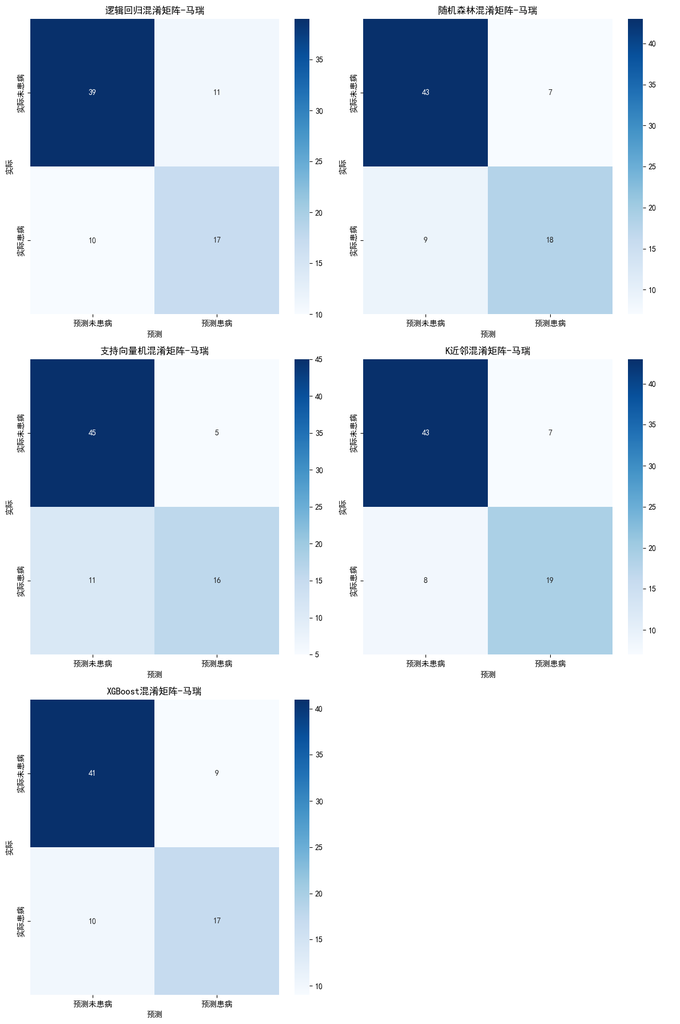

```python
from sklearn.metrics import confusion_matrix
import seaborn as sns
import matplotlib.pyplot as plt

def plot_confusion_matrix(y_true, y_pred, title, ax):
    cm = confusion_matrix(y_true, y_pred)
    sns.heatmap(cm, annot=True, fmt='d', cmap='Blues',
                xticklabels=['预测未患病', '预测患病'],
                yticklabels=['实际未患病', '实际患病'],
                ax=ax)
    ax.set_xlabel('预测')
    ax.set_ylabel('实际')
    ax.set_title(title)
# 创建一个3x2的子图布局
fig, axes = plt.subplots(3, 2, figsize=(12, 18))

# 为每个模型绘制混淆矩阵
plot_confusion_matrix(y_test, lr_grid.best_estimator_.predict(X_test), '逻辑回归混淆矩阵-马瑞', axes[0, 0])
plot_confusion_matrix(y_test, rf_grid.best_estimator_.predict(X_test), '随机森林混淆矩阵-马瑞', axes[0, 1])
plot_confusion_matrix(y_test, svc_grid.best_estimator_.predict(X_test), '支持向量机混淆矩阵-马瑞', axes[1, 0])
plot_confusion_matrix(y_test, knn_grid.best_estimator_.predict(X_test), 'K近邻混淆矩阵-马瑞', axes[1, 1])
plot_confusion_matrix(y_test, xgb_grid.best_estimator_.predict(X_test), 'XGBoost混淆矩阵-马瑞', axes[2, 0])

# 隐藏最后一个空的子图
axes[2, 1].axis('off')

# 调整子图之间的间距
plt.tight_layout()

# 显示图形
plt.show()
```

#### 绘制多个模型的 ROC 曲线

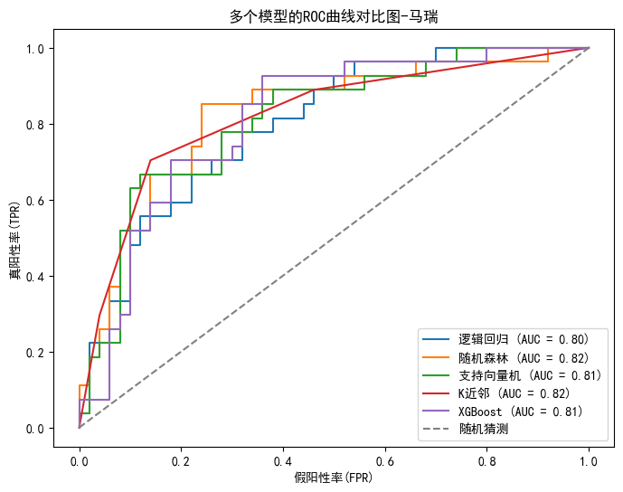

```python
from sklearn.metrics import roc_curve, roc_auc_score
import matplotlib.pyplot as plt

# 定义函数绘制 ROC 曲线
def plot_roc_curve_multiple(y_true, models, model_names, X_test):
    plt.figure(figsize=(8, 6))
    for model, name in zip(models, model_names):
        y_pred_prob = model.predict_proba(X_test)[:, 1]
        fpr, tpr, _ = roc_curve(y_true, y_pred_prob)
        auc_score = roc_auc_score(y_true, y_pred_prob)
        plt.plot(fpr, tpr, label=f'{name} (AUC = {auc_score:.2f})')

    plt.plot([0, 1], [0, 1], linestyle='--', color='gray', label='随机猜测')
    plt.xlabel('假阳性率(FPR)')
    plt.ylabel('真阳性率(TPR)')
    plt.title('多个模型的ROC曲线对比图-马瑞')
    plt.legend()
    plt.show()

# 模型列表
models = [
    lr_grid.best_estimator_,
    rf_grid.best_estimator_,
    svc_grid.best_estimator_,
    knn_grid.best_estimator_,
    xgb_grid.best_estimator_
]
model_names = ['逻辑回归', '随机森林', '支持向量机', 'K近邻', 'XGBoost']

# 绘制 ROC 曲线
plot_roc_curve_multiple(y_test, models, model_names, X_test)
```

#### 多个模型的分类报告

```python
from sklearn.metrics import classification_report
from prettytable import PrettyTable

def generate_classification_report_table(y_true, models, model_names, X_test):
    reports = []
    for model, name in zip(models, model_names):
        y_pred = model.predict(X_test)
        report = classification_report(y_true, y_pred, output_dict=True)
        report_df = pd.DataFrame(report).transpose()
        report_df['Model'] = name
        reports.append(report_df)

    # 合并所有报告
    final_report = pd.concat(reports)

    # 调整格式
    final_report = final_report.reset_index().set_index(['Model', 'index'])  # 将 Model 和 index 作为多级索引
    final_report = final_report[['precision', 'recall', 'f1-score', 'support']]  # 只保留关键指标
    final_report = final_report.round(2)  # 将数值格式化为两位小数

    # 过滤掉 accuracy、macro avg 和 weighted avg
    final_report = final_report.loc[(slice(None), ['0', '1']), :]

    return final_report

# 生成分类报告表格
report_table = generate_classification_report_table(y_test, models, model_names, X_test)

# 创建两个表格，分别对比 Class 0 和 Class 1
table_class_0 = PrettyTable()
table_class_0.field_names = ['Model', 'Class', 'Precision', 'Recall', 'F1-Score', 'Support']

table_class_1 = PrettyTable()
table_class_1.field_names = ['Model', 'Class', 'Precision', 'Recall', 'F1-Score', 'Support']

# 填充表格
for (model, cls), row in report_table.iterrows():
    if cls == '0':
        table_class_0.add_row([model, cls, row['precision'], row['recall'], row['f1-score'], row['support']])
    elif cls == '1':
        table_class_1.add_row([model, cls, row['precision'], row['recall'], row['f1-score'], row['support']])

# 打印表格
print("多个模型的分类报告-马瑞")
print("Class 0 Comparison:")
print(table_class_0)
print("\nClass 1 Comparison:")
print(table_class_1)
```

```
多个模型的分类报告-马瑞
Class 0 Comparison:
+------------+-------+-----------+--------+----------+---------+
|   Model    | Class | Precision | Recall | F1-Score | Support |
+------------+-------+-----------+--------+----------+---------+
|  逻辑回归  |   0   |    0.8    |  0.78  |   0.79   |   50.0  |
|  随机森林  |   0   |    0.83   |  0.86  |   0.84   |   50.0  |
| 支持向量机 |   0   |    0.8    |  0.9   |   0.85   |   50.0  |
|   K近邻    |   0   |    0.84   |  0.86  |   0.85   |   50.0  |
|  XGBoost   |   0   |    0.8    |  0.82  |   0.81   |   50.0  |
+------------+-------+-----------+--------+----------+---------+

Class 1 Comparison:
+------------+-------+-----------+--------+----------+---------+
|   Model    | Class | Precision | Recall | F1-Score | Support |
+------------+-------+-----------+--------+----------+---------+
|  逻辑回归  |   1   |    0.61   |  0.63  |   0.62   |   27.0  |
|  随机森林  |   1   |    0.72   |  0.67  |   0.69   |   27.0  |
| 支持向量机 |   1   |    0.76   |  0.59  |   0.67   |   27.0  |
|   K近邻    |   1   |    0.73   |  0.7   |   0.72   |   27.0  |
|  XGBoost   |   1   |    0.65   |  0.63  |   0.64   |   27.0  |
+------------+-------+-----------+--------+----------+---------+
```

#### 绘制多个模型的精确率-召回率曲线

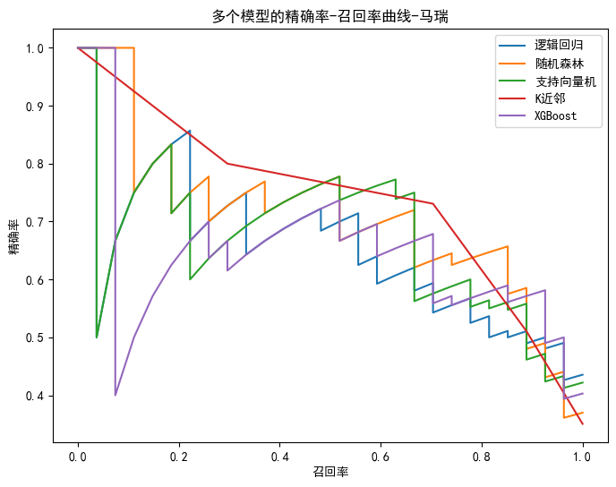

```python
from sklearn.metrics import precision_recall_curve
import matplotlib.pyplot as plt

# 定义函数绘制精确率-召回率曲线
def plot_precision_recall_curve_multiple(y_true, models, model_names, X_test):
    plt.figure(figsize=(8, 6))
    for model, name in zip(models, model_names):
        y_pred_prob = model.predict_proba(X_test)[:, 1]
        precision, recall, _ = precision_recall_curve(y_true, y_pred_prob)
        plt.plot(recall, precision, label=f'{name}')

    plt.xlabel('召回率')
    plt.ylabel('精确率')
    plt.title('多个模型的精确率-召回率曲线-马瑞')
    plt.legend()
    plt.show()

# 绘制精确率-召回率曲线
plot_precision_recall_curve_multiple(y_test, models, model_names, X_test)
```

### 实验改进 - 过采样

但是从上述结果也能看出Class = 1时的指标较低，下面我们组将通过**过采样**的方法来提高这一指标。

```python
from imblearn.over_sampling import SMOTE
from collections import Counter

# 初始化 SMOTE
smote = SMOTE(random_state=42)

# 对训练数据进行过采样
X_train_resampled, y_train_resampled = smote.fit_resample(X_train, y_train)

# 查看过采样后的类别分布
print('过采样后的类别分布:', Counter(y_train_resampled))
```

```
过采样后的类别分布: Counter({1: 450, 0: 450})
```

#### 重新训练

```python
# 随机森林
rf_model_resampled = RandomForestClassifier(random_state=42)
rf_model_resampled.fit(X_train_resampled, y_train_resampled)

# XGBoost
xgb_model_resampled = XGBClassifier(random_state=42)
xgb_model_resampled.fit(X_train_resampled, y_train_resampled)
# 随机森林
y_pred_rf = rf_model_resampled.predict(X_test)

# XGBoost
y_pred_xgb = xgb_model_resampled.predict(X_test)
```

#### 绘制混淆矩阵

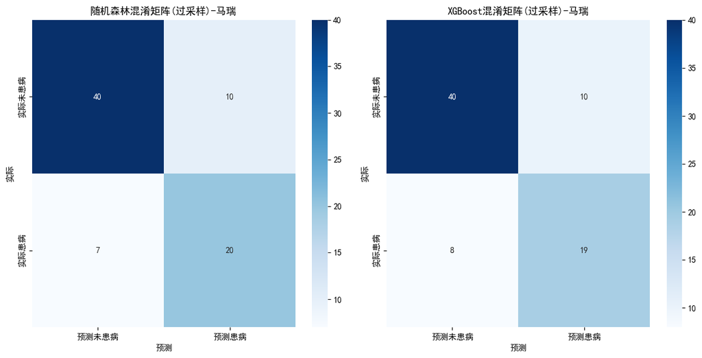

```python
# 绘制混淆矩阵
def plot_confusion_matrix(y_true, y_pred, title, ax):
    cm = confusion_matrix(y_true, y_pred)
    sns.heatmap(cm, annot=True, fmt='d', cmap='Blues',
                xticklabels=['预测未患病', '预测患病'],
                yticklabels=['实际未患病', '实际患病'],
                ax=ax)
    ax.set_xlabel('预测')
    ax.set_ylabel('实际')
    ax.set_title(title)

# 创建一个1x2的子图布局
fig, axes = plt.subplots(1, 2, figsize=(12, 6))

# 为每个模型绘制混淆矩阵
plot_confusion_matrix(y_test, y_pred_rf, '随机森林混淆矩阵(过采样)-马瑞', axes[0])
plot_confusion_matrix(y_test, y_pred_xgb, 'XGBoost混淆矩阵(过采样)-马瑞', axes[1])

# 调整子图之间的间距
plt.tight_layout()

# 显示图形
plt.show()
```

#### 绘制ROC曲线

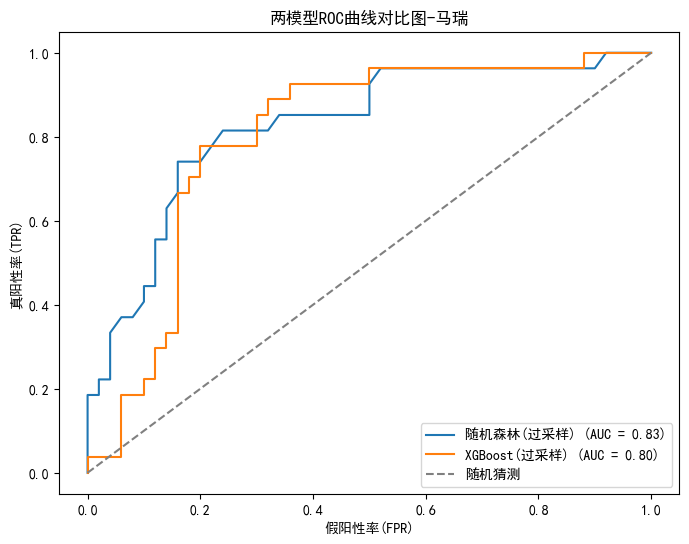

```python
from sklearn.metrics import roc_curve, roc_auc_score
import matplotlib.pyplot as plt

def plot_roc_curve_multiple(y_true, models, model_names, X_test):
    plt.figure(figsize=(8, 6))
    for model, name in zip(models, model_names):
        y_pred_prob = model.predict_proba(X_test)[:, 1]
        fpr, tpr, _ = roc_curve(y_true, y_pred_prob)
        auc_score = roc_auc_score(y_true, y_pred_prob)
        plt.plot(fpr, tpr, label=f'{name} (AUC = {auc_score:.2f})')

    plt.plot([0, 1], [0, 1], linestyle='--', color='gray', label='随机猜测')
    plt.xlabel('假阳性率(FPR)')
    plt.ylabel('真阳性率(TPR)')
    plt.title('两模型ROC曲线对比图-马瑞')
    plt.legend()
    plt.show()

# 模型列表
models = [rf_model_resampled, xgb_model_resampled]
model_names = ['随机森林(过采样)', 'XGBoost(过采样)']

# 绘制 ROC 曲线
plot_roc_curve_multiple(y_test, models, model_names, X_test)
```

#### 整合分类报告

```python
from sklearn.metrics import classification_report
from prettytable import PrettyTable
import pandas as pd

def generate_classification_report_table(y_true, models, model_names, X_test):
    reports = []
    for model, name in zip(models, model_names):
        y_pred = model.predict(X_test)
        report = classification_report(y_true, y_pred, output_dict=True)
        report_df = pd.DataFrame(report).transpose()
        report_df['Model'] = name
        reports.append(report_df)

    # 合并所有报告
    final_report = pd.concat(reports)

    # 调整格式
    final_report = final_report.reset_index().set_index(['Model', 'index'])  # 将 Model 和 index 作为多级索引
    final_report = final_report[['precision', 'recall', 'f1-score', 'support']]  # 只保留关键指标
    final_report = final_report.round(2)  # 将数值格式化为两位小数

    # 过滤掉 accuracy、macro avg 和 weighted avg
    final_report = final_report.loc[(slice(None), ['0', '1']), :]

    return final_report

# 生成分类报告表格
report_table = generate_classification_report_table(y_test, models, model_names, X_test)

# 创建两个表格，分别对比 Class 0 和 Class 1
table_class_0 = PrettyTable()
table_class_0.field_names = ['Model', 'Precision', 'Recall', 'F1-Score', 'Support']

table_class_1 = PrettyTable()
table_class_1.field_names = ['Model', 'Precision', 'Recall', 'F1-Score', 'Support']

# 填充表格
for (model, cls), row in report_table.iterrows():
    if cls == '0':
        table_class_0.add_row([model, row['precision'], row['recall'], row['f1-score'], row['support']])
    elif cls == '1':
        table_class_1.add_row([model, row['precision'], row['recall'], row['f1-score'], row['support']])

# 打印表格
print("Class 0 Comparison:")
print(table_class_0)
print("\nClass 1 Comparison:")
print(table_class_1)
```

```
Class 0 Comparison:
+------------------+-----------+--------+----------+---------+
|      Model       | Precision | Recall | F1-Score | Support |
+------------------+-----------+--------+----------+---------+
| 随机森林(过采样) |    0.85   |  0.8   |   0.82   |   50.0  |
| XGBoost(过采样)  |    0.83   |  0.8   |   0.82   |   50.0  |
+------------------+-----------+--------+----------+---------+

Class 1 Comparison:
+------------------+-----------+--------+----------+---------+
|      Model       | Precision | Recall | F1-Score | Support |
+------------------+-----------+--------+----------+---------+
| 随机森林(过采样) |    0.67   |  0.74  |   0.7    |   27.0  |
| XGBoost(过采样)  |    0.66   |  0.7   |   0.68   |   27.0  |
+------------------+-----------+--------+----------+---------+
```

#### 绘制精确率-召回率曲线

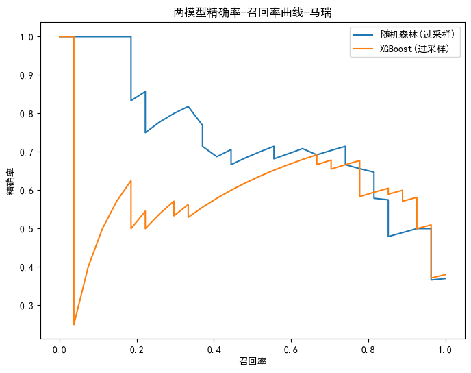

```python
def plot_precision_recall_curve_multiple(y_true, models, model_names, X_test):
    plt.figure(figsize=(8, 6))
    for model, name in zip(models, model_names):
        y_pred_prob = model.predict_proba(X_test)[:, 1]
        precision, recall, _ = precision_recall_curve(y_true, y_pred_prob)
        plt.plot(recall, precision, label=f'{name}')

    plt.xlabel('召回率')
    plt.ylabel('精确率')
    plt.title('两模型精确率-召回率曲线-马瑞')
    plt.legend()
    plt.show()

# 模型列表
models = [rf_model_resampled, xgb_model_resampled]
model_names = ['随机森林(过采样)', 'XGBoost(过采样)']

# 绘制精确率-召回率曲线
plot_precision_recall_curve_multiple(y_test, models, model_names, X_test)
```

### 实验改进 - 随机欠采样

从过采样的结果可以看出，模型的效果有了改善但仍然存在提升空间，尤其是XGBoost模型，过采样后模型效果提升不明显。因此我们决定继续探索其他方法，尝试提升模型效果。

我们选择尝试随机欠采样法，欠采样是从多数类中随机选择部分样本，使得两类样本数量更加均衡。这样可以使得模型在训练过程中不会过度偏向于多数类（未患病），从而提高对少数类（患病）的预测能力。

```python
from imblearn.under_sampling import RandomUnderSampler

# 初始化欠采样
undersampler = RandomUnderSampler(random_state=42)

# 对训练数据进行欠采样
X_train_undersampled, y_train_undersampled = undersampler.fit_resample(X_train, y_train)

# 查看欠采样后的类别分布
print('欠采样后的类别分布:', Counter(y_train_undersampled))
```

```
欠采样后的类别分布: Counter({0: 241, 1: 241})
```

#### 训练模型

使用欠采样处理后的训练集，训练前面用到的5个模型。

```python
from sklearn.preprocessing import StandardScaler
from sklearn.feature_selection import SelectKBest, f_classif

# 标准化特征
scaler = StandardScaler()
X_train_scaled = scaler.fit_transform(X_train_undersampled)
X_test_scaled = scaler.transform(X_test)

# 特征选择
selector = SelectKBest(score_func=f_classif, k=8)
X_train_selected = selector.fit_transform(X_train_scaled, y_train_undersampled)
X_test_selected = selector.transform(X_test_scaled)

# 训练逻辑回归模型
lr_US_model = LogisticRegression(random_state=42, class_weight='balanced')
lr_US_model.fit(X_train_selected, y_train_undersampled)
y_US_pred_lr = lr_US_model.predict(X_test_selected)

# 训练随机森林模型
rf_US_model = RandomForestClassifier(random_state=42, class_weight='balanced')
rf_US_model.fit(X_train_selected, y_train_undersampled)
y_US_pred_rf = rf_US_model.predict(X_test_selected)

# 训练支持向量机模型
svc_US_model = SVC(random_state=42, class_weight='balanced', probability=True)
svc_US_model.fit(X_train_selected, y_train_undersampled)
y_pred_US_svc = svc_US_model.predict(X_test_selected)

# 训练K近邻模型
knn_US_model = KNeighborsClassifier(weights='distance')
knn_US_model.fit(X_train_selected, y_train_undersampled)
y_US_pred_knn = knn_US_model.predict(X_test_selected)

# 训练XGBoost模型
xgb_US_model = XGBClassifier(random_state=42, use_label_encoder=False, eval_metric='logloss', scale_pos_weight=500/268)
xgb_US_model.fit(X_train_selected, y_train_undersampled)
y_US_pred_xgb = xgb_US_model.predict(X_test_selected)
```

#### 混淆矩阵

从混淆矩阵中可以看出，所有模型在未患病样本中的精确率都有提升，召回率有所降低；而在患病样本中的精确率都有降低但召回率有所提升。与未处理过的数据集相比，模型预测未患病人群的准确率有提升，但在患病人群中准确率有所降低。

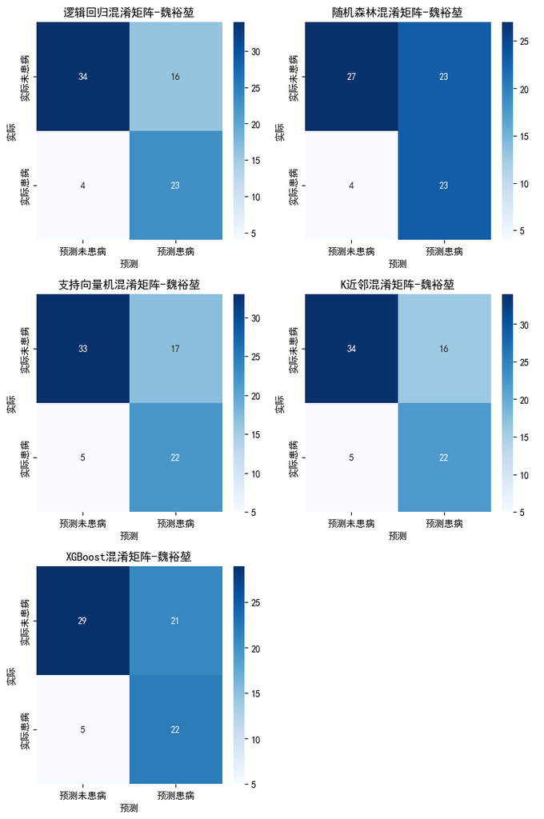

```python
undersalample_models = [
    lr_US_model,
    rf_US_model,
    svc_US_model,
    knn_US_model,
    xgb_US_model
]
models_names = ['逻辑回归', '随机森林', '支持向量机', 'K近邻', 'XGBoost']

# 创建3x2的子图布局
fig, axes = plt.subplots(nrows=3, ncols=2, figsize=(8, 12))

# 遍历所有模型生成混淆矩阵
for i, model in enumerate(undersalample_models):
    # 进行预测
    y_test_pred = model.predict(X_test)

    # 计算混淆矩阵
    conf_matrix = confusion_matrix(y_test, y_test_pred)

    # 获取子图的行和列位置
    row = i // 2
    col = i % 2

    # 绘制混淆矩阵
    sns.heatmap(conf_matrix, annot=True, fmt='d', cmap='Blues', xticklabels=['预测未患病', '预测患病'], yticklabels=['实际未患病', '实际患病'], ax=axes[row, col])
    axes[row, col].set_title(f'{models_names[i]}混淆矩阵-魏裕堃')
    axes[row, col].set_xlabel('预测')
    axes[row, col].set_ylabel('实际')

axes[2, 1].axis('off')
# 调整子图之间的间距
plt.tight_layout()
plt.show()
```

#### ROC曲线对比图

从ROC曲线和AUC值来看，与未处理过的数据集相比，逻辑回归、支持向量机两个模型的效果有较小的提升，而其他三个模型的效果有所降低。

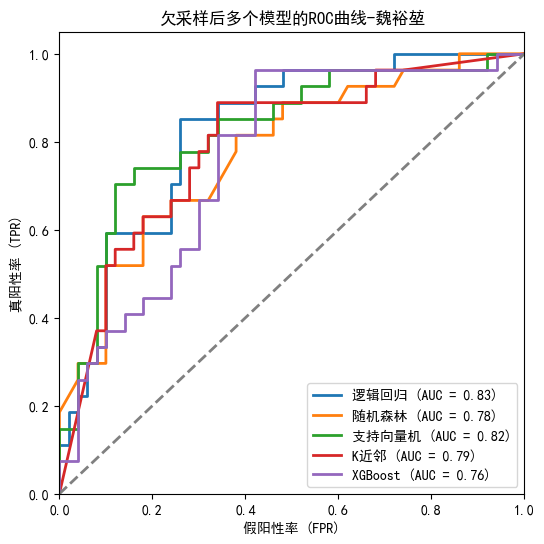

```python
# 创建一个图和轴
plt.figure(figsize=(6, 6))

# 遍历所有模型生成ROC曲线
for model, name in zip(undersalample_models, models_names):
    # 如果模型是逻辑回归或支持向量机，它们可以直接输出概率
    if isinstance(model, (LogisticRegression, SVC)):
        y_prob = model.predict_proba(X_test)[:, 1]
    elif isinstance(model, RandomForestClassifier):
        y_prob = model.predict_proba(X_test)[:, 1]
    elif isinstance(model, KNeighborsClassifier):
        y_prob = model.predict_proba(X_test)[:, 1]
    elif isinstance(model, XGBClassifier):
        y_prob = model.predict_proba(X_test)[:, 1]
    else:
        raise ValueError("未知的模型类型")

    # 计算ROC曲线和AUC值
    fpr, tpr, thresholds = roc_curve(y_test, y_prob)
    roc_auc = roc_auc_score(y_test, y_prob)

    # 绘制ROC曲线
    plt.plot(fpr, tpr, lw=2, label=f'{name} (AUC = {roc_auc:.2f})')

# 绘制对角线
plt.plot([0, 1], [0, 1], color='gray', lw=2, linestyle='--')

# 设置图的属性
plt.xlim([0.0, 1.0])
plt.ylim([0.0, 1.05])
plt.xlabel('假阳性率 (FPR)')
plt.ylabel('真阳性率 (TPR)')
plt.title('欠采样后多个模型的ROC曲线-魏裕堃')
plt.legend(loc='lower right')

# 显示图形
plt.show()
```

#### 精确率-召回率曲线对比图

从精确率-召回率曲线来看，与未处理过的数据集相比，模型的效果大体上相同。

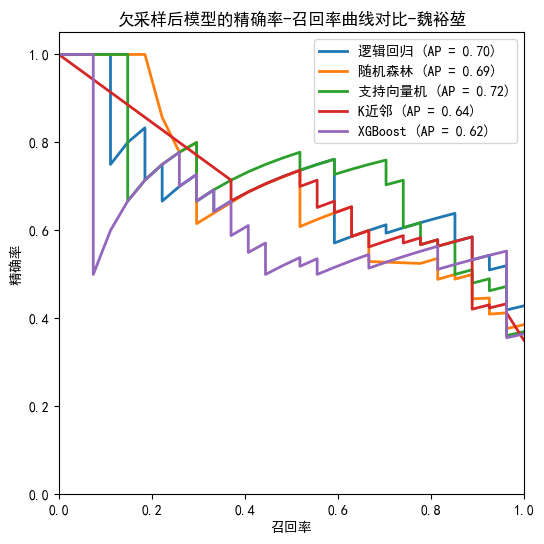

```python
import matplotlib.pyplot as plt
from sklearn.metrics import precision_recall_curve, average_precision_score


# 创建一个图和轴
plt.figure(figsize=(6, 6))

# 遍历所有模型生成PR曲线
for model, name in zip(undersalample_models, models_names):
    # 如果模型是逻辑回归或支持向量机，它们可以直接输出概率
    if isinstance(model, (LogisticRegression, SVC)):
        y_prob = model.predict_proba(X_test)[:, 1]
    elif isinstance(model, RandomForestClassifier):
        y_prob = model.predict_proba(X_test)[:, 1]
    elif isinstance(model, KNeighborsClassifier):
        y_prob = model.predict_proba(X_test)[:, 1]
    elif isinstance(model, XGBClassifier):
        y_prob = model.predict_proba(X_test)[:, 1]
    else:
        raise ValueError("未知的模型类型")

    # 计算PR曲线和平均精度
    precision, recall, thresholds = precision_recall_curve(y_test, y_prob)
    avg_precision = average_precision_score(y_test, y_prob)

    # 绘制PR曲线
    plt.plot(recall, precision, lw=2, label=f'{name} (AP = {avg_precision:.2f})')

# 设置图的属性
plt.xlim([0.0, 1.0])
plt.ylim([0.0, 1.05])
plt.xlabel('召回率')
plt.ylabel('精确率')
plt.title('欠采样后模型的精确率-召回率曲线对比-魏裕堃')
plt.legend(loc='best')

# 显示图形
plt.show()
```

#### 分类报告

通过分类报告给出的具体数据，我们可以得出以下结论：

- 对于类别1（患病），模型召回率大幅提升，更擅长识别患病样本，减少漏诊风险。但精确率下降，有着更高的假阳性率。
- 对于类别0（未患病），模型召回率降低，对未患病样本的识别能力下降，可能导致过度诊断。
- 若任务更关注患病样本的检出率（如疾病筛查），欠采样后的模型更合适；若需平衡精确率和召回率，则需要探索其他方法。

```python
from sklearn.metrics import classification_report
import pandas as pd

# 初始化存储容器
class0_data = []
class1_data = []

# 遍历所有模型生成报告
for model in undersalample_models:
    # 根据模型类型预测测试集的类别
    if isinstance(model, (LogisticRegression, RandomForestClassifier, SVC, KNeighborsClassifier)):
        y_pred = model.predict(X_test_selected)
    elif isinstance(model, XGBClassifier):
        y_pred = model.predict(X_test_selected)
    else:
        raise ValueError("未知的模型类型")

    # 生成分类报告字典
    report = classification_report(y_test, y_pred, output_dict=True)

    # 提取类别0指标
    class0 = report['0']
    class0_data.append({
        'Model': model.__class__.__name__,
        'Precision': round(class0['precision'], 3),
        'Recall': round(class0['recall'], 3),
        'F1-Score': round(class0['f1-score'], 3),
        'Support': int(class0['support'])
    })

    # 提取类别1指标
    class1 = report['1']
    class1_data.append({
        'Model': model.__class__.__name__,
        'Precision': round(class1['precision'], 3),
        'Recall': round(class1['recall'], 3),
        'F1-Score': round(class1['f1-score'], 3),
        'Support': int(class1['support'])
    })

# 创建DataFrame并打印结果
df_class0 = pd.DataFrame(class0_data)
df_class1 = pd.DataFrame(class1_data)

print("分类报告（欠采样）-魏裕堃".center(50))
print("▂" * 40)
print("类别 0 - 未患病".center(50))
print(df_class0.to_string(index=False))
print("\n" + "▂" * 40)
print("类别 1 - 患病".center(50))
print(df_class1.to_string(index=False))
print("▂" * 40)
```

```
                  分类报告（欠采样）-魏裕堃
▂▂▂▂▂▂▂▂▂▂▂▂▂▂▂▂▂▂▂▂▂▂▂▂▂▂▂▂▂▂▂▂▂▂▂▂▂▂▂▂
                    类别 0 - 未患病
                 Model  Precision  Recall  F1-Score  Support
    LogisticRegression      0.860    0.74     0.796       50
RandomForestClassifier      0.861    0.62     0.721       50
                   SVC      0.865    0.64     0.736       50
  KNeighborsClassifier      0.805    0.66     0.725       50
         XGBClassifier      0.909    0.60     0.723       50

▂▂▂▂▂▂▂▂▂▂▂▂▂▂▂▂▂▂▂▂▂▂▂▂▂▂▂▂▂▂▂▂▂▂▂▂▂▂▂▂
                    类别 1 - 患病
                 Model  Precision  Recall  F1-Score  Support
    LogisticRegression      0.618   0.778     0.689       27
RandomForestClassifier      0.537   0.815     0.647       27
                   SVC      0.550   0.815     0.657       27
  KNeighborsClassifier      0.528   0.704     0.603       27
         XGBClassifier      0.545   0.889     0.676       27
▂▂▂▂▂▂▂▂▂▂▂▂▂▂▂▂▂▂▂▂▂▂▂▂▂▂▂▂▂▂▂▂▂▂▂▂▂▂▂▂
```

### 展望

由上面的分析可以得出，欠采样通过减少多数类样本数量，显著提升了模型对少数类（患病）的识别能力，但代价是多数类（未患病）的性能下降。需根据实际需求（如医疗场景中更关注召回率）选择模型，并进一步通过阈值调整或集成方法优化性能。

对于进一步改进方向，可以考虑通过混合采样方法如‌SMOTE-Tomek、SMOTE-ENN或是更换数据集的方法来进一步提升模型的性能。